# Illustrating linear regression

Steve Simon

October 8, 2017

This program illustrates how to run various simple linear regression models in R.

Install these libraries if you do not already have them.

```r
install.packages("broom")
install.packages("dplyr")
install.packages("ggplot2")
install.packages("magrittr")
```

The datasets you see below are described at

http://lib.stat.cmu.edu/DASL/Datafiles/homedat.html

https://ww2.amstat.org/publications/jse/datasets/fev.txt

```r
fn <- "http://lib.stat.cmu.edu/DASL/Datafiles/homedat.html"
ab <- read.table(file=fn, header=FALSE, as.is=TRUE, sep="~")
tabbed_lines <- grepl("\\t", ab$V1)
write.table(ab[tabbed_lines, ],
  file="albuquerque.tsv", quote=FALSE,
  col.names=FALSE, row.names=FALSE)
ab <- read.table(file="albuquerque.tsv", header=FALSE, as.is=TRUE)
names(ab) <- c("price", "sqft", "age", "feats", "ne", "cust", "corner", "taxes")
head(ab)
```

```
##   price sqft age feats ne cust corner taxes
## 1  2050 2650  13     7  1    1      0  1639
## 2  2080 2600   *     4  1    1      0  1088
## 3  2150 2664   6     5  1    1      0  1193
## 4  2150 2921   3     6  1    1      0  1635
## 5  1999 2580   4     4  1    1      0  1732
## 6  1900 2580   4     4  1    0      0  1534
```

```r
ab$price <- ab$price*100
ab$age <- as.numeric(ab$age)
fn <- "http://www.amstat.org/publications/jse/datasets/fev.dat.txt"
pu <- read.table(file=fn)
```

There are no variable names at the top of this file, but you can add them based on the description. You also can create factors for the two categorical variables, smoke and sex.

```r
names(pu) <- c("age","fev","ht","sex","smoke")
pu$smoke.factor <- factor(pu$smoke, levels=0:1,    labels=c("nonsmoker", "smoker"))
pu$sex.factor <- factor(pu$sex, levels=0:1,    labels=c("female", "male"))

head(pu)
```

```
##   age   fev   ht sex smoke smoke.factor sex.factor
## 1   9 1.708 57.0   0     0    nonsmoker     female
## 2   8 1.724 67.5   0     0    nonsmoker     female
## 3   7 1.720 54.5   0     0    nonsmoker     female
## 4   9 1.558 53.0   1     0    nonsmoker       male
## 5   9 1.895 57.0   1     0    nonsmoker       male
## 6   8 2.336 61.0   0     0    nonsmoker     female
```

```r
tail(pu)
```

```
##     age   fev   ht sex smoke smoke.factor sex.factor
## 649  16 4.872 72.0   1     1       smoker       male
## 650  16 4.270 67.0   1     1       smoker       male
## 651  15 3.727 68.0   1     1       smoker       male
## 652  18 2.853 60.0   0     0    nonsmoker     female
## 653  16 2.795 63.0   0     1       smoker     female
## 654  15 3.211 66.5   0     0    nonsmoker     female
```

```r
summary(pu)
```

```
##       age              fev              ht             sex
##  Min.   : 3.000   Min.   :0.791   Min.   :46.00   Min.   :0.0000
##  1st Qu.: 8.000   1st Qu.:1.981   1st Qu.:57.00   1st Qu.:0.0000
##  Median :10.000   Median :2.547   Median :61.50   Median :1.0000
##  Mean   : 9.931   Mean   :2.637   Mean   :61.14   Mean   :0.5138
##  3rd Qu.:12.000   3rd Qu.:3.119   3rd Qu.:65.50   3rd Qu.:1.0000
##  Max.   :19.000   Max.   :5.793   Max.   :74.00   Max.   :1.0000
##      smoke            smoke.factor  sex.factor
##  Min.   :0.00000   nonsmoker:589   female:318
##  1st Qu.:0.00000   smoker   : 65   male  :336
##  Median :0.00000
##  Mean   :0.09939
##  3rd Qu.:0.00000
##  Max.   :1.00000
```

Does the size of a house (sqft) help predict the sales price? First, draw a graph.

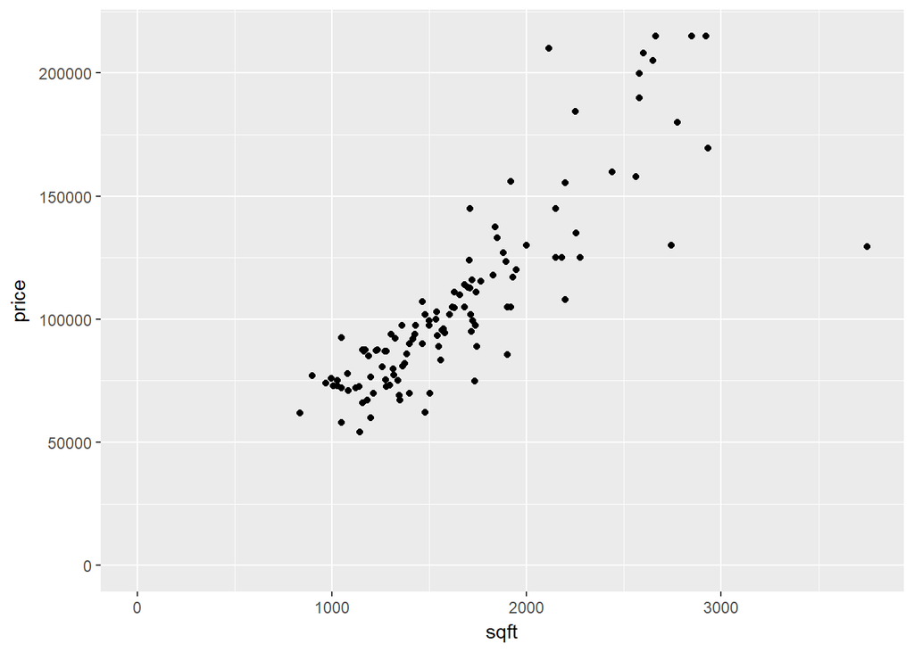

```r
library(ggplot2)
ggplot(data=ab, aes(x=sqft, y=price)) +
  expand_limits(x=0, y=0) +
  geom_point() -> sqft_graph
print(sqft_graph)
```

The lm function computes a linear regression model and stores the relevant information in a list. Use the print function to get a brief description of the model and the summary functiton to get a more detailed description.

```r
sqft_model <- lm(price~sqft, data=ab)
print(sqft_model)
```

```
##
## Call:
## lm(formula = price ~ sqft, data = ab)
##
## Coefficients:
## (Intercept)         sqft
##     4781.93        61.37
```

```r
summary(sqft_model)
```

```
##
## Call:
## lm(formula = price ~ sqft, data = ab)
##
## Residuals:
##     Min      1Q  Median      3Q     Max
## -105407   -9906     668    6942   75366
##
## Coefficients:
##             Estimate Std. Error t value Pr(>|t|)
## (Intercept) 4781.931   6285.482   0.761    0.448
## sqft          61.367      3.625  16.931   <2e-16 ***
## ---
## Signif. codes:  0 '***' 0.001 '**' 0.01 '*' 0.05 '.' 0.1 ' ' 1
##
## Residual standard error: 20450 on 115 degrees of freedom
## Multiple R-squared:  0.7137, Adjusted R-squared:  0.7112
## F-statistic: 286.6 on 1 and 115 DF,  p-value: < 2.2e-16
```

```r
names(sqft_model)
```

```
##  [1] "coefficients"  "residuals"     "effects"       "rank"
##  [5] "fitted.values" "assign"        "qr"            "df.residual"
##  [9] "xlevels"       "call"          "terms"         "model"
```

It is tricky to extract information from the linear regression model (or any statistical model in R). The broom library makes this extraction process easier. It works with a wide range of models in R. The glance function provides a single line summary of the model. The tidy function provides a tibble (a fancy data frame) with one row for each coefficient in the model. The augment function adds predicted values and residuals to the original data frame or produces predicted values for a data frame with new values.

```r
library(broom)
library(dplyr)
library(magrittr)
glance(sqft_model)
```

```
##   r.squared adj.r.squared    sigma statistic      p.value df    logLik
## 1 0.7136788      0.711189 20445.12  286.6468 5.146346e-33  2 -1326.291
##        AIC      BIC    deviance df.residual
## 1 2658.581 2666.868 48070320866         115
```

```r
sqft_coefficients <- tidy(sqft_model)
sqft_coefficients
```

```
##          term   estimate   std.error  statistic      p.value
## 1 (Intercept) 4781.93066 6285.481916  0.7607898 4.483397e-01
## 2        sqft   61.36668    3.624592 16.9306457 5.146346e-33
```

```r
sqft_predictions <- augment(sqft_model)
head(sqft_predictions)
```

```
##    price sqft  .fitted  .se.fit   .resid       .hat   .sigma    .cooksd
## 1 205000 2650 167403.6 4075.445 37596.37 0.03973479 20217.75 0.07285696
## 2 208000 2600 164335.3 3915.788 43664.70 0.03668251 20107.41 0.09015129
## 3 215000 2664 168262.8 4120.469 46737.23 0.04061758 20042.38 0.11530479
## 4 215000 2921 184034.0 4966.615 30965.99 0.05901219 20315.77 0.07644246
## 5 199900 2580 163108.0 3852.459 36792.03 0.03550561 20232.60 0.06180106
## 6 190000 2580 163108.0 3852.459 26892.03 0.03550561 20373.81 0.03301685
##   .std.resid
## 1   1.876552
## 2   2.175986
## 3   2.333875
## 4   1.561361
## 5   1.832375
## 6   1.339319
```

```r
sqft_new_predictions <- augment(sqft_model, newdata=data.frame(sqft=c(0, 1000, 2000, 3000)))
sqft_new_predictions
```

```
##   sqft    .fitted  .se.fit
## 1    0   4781.931 6285.482
## 2 1000  66148.612 3031.397
## 3 2000 127515.292 2268.652
## 4 3000 188881.973 5232.546
```

You can add the linear regression line to your plot easily.

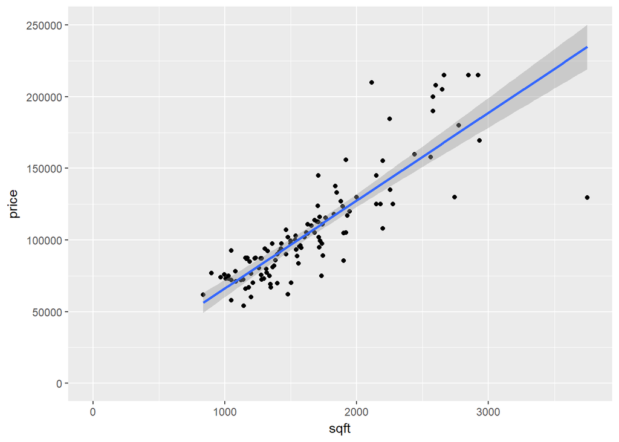

```r
sqft_graph + geom_smooth(method=lm)
```

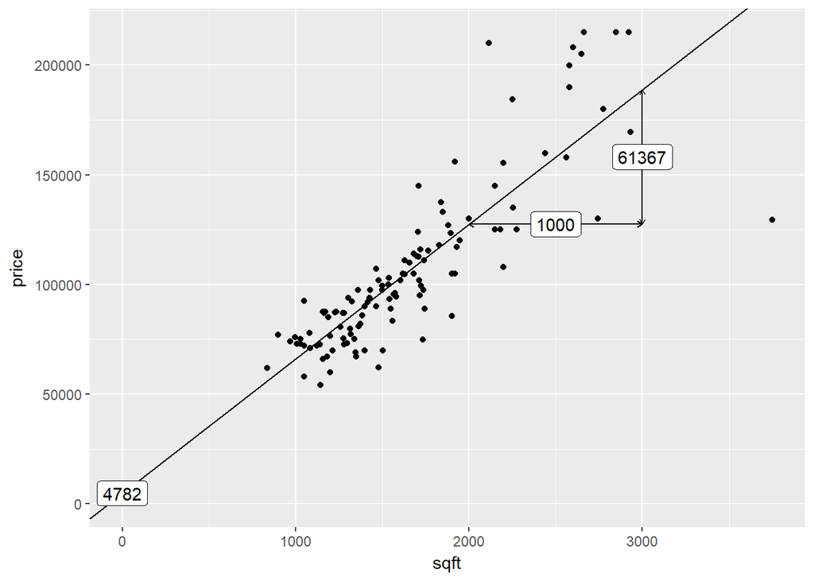

```r
sqft_coefficients %>%
  filter(term=="(Intercept)") %>%
  select(estimate) %>%
  as.numeric -> sqft_intercept
sqft_coefficients %>%
  filter(term=="sqft") %>%
  select(estimate) %>%
  as.numeric -> sqft_slope
sqft_new_predictions %>%
  filter(sqft==2000) %>%
  select(.fitted) %>%
  as.numeric -> predict_at_2000
sqft_new_predictions %>%
  filter(sqft==3000) %>%
  select(.fitted) %>%
  as.numeric -> predict_at_3000
predict_midpoint <- (predict_at_2000 + predict_at_3000) / 2
predict_difference <- predict_at_3000 - predict_at_2000
sqft_graph +
  geom_abline(slope=sqft_slope, intercept=sqft_intercept) +
  geom_label(aes(x=0, y=sqft_intercept, label=round(sqft_intercept))) +
  geom_segment(x=2000, y=predict_at_2000, xend=3000, yend=predict_at_2000,
    arrow=arrow(ends="both", length=unit(0.05, "inches"))) +
  geom_label(x=2500, y=predict_at_2000, label="1000") +
  geom_segment(x=3000, y=predict_at_2000, xend=3000, yend=predict_at_3000,
    arrow=arrow(ends="both", length=unit(0.05, "inches"))) +
  geom_label(x=3000, y=predict_midpoint, label=round(predict_difference))
```

The slope in a linear regression model is the estimated average change in Y when X increases by 1 unit. For the sqft model, it says that for each additional square foot of room in your house, you get an additional 61 dollars in your price.

The intercept in a linear regression model is the estimated average value of Y when X equals 0. In the sqft model, it says that the estimated average price of a house with zero square feet is 4782 dollars. Interpretation of the intercept is tricky when the range of the independent variable does not inlcude zero.

It is often useful to plot the predicted values versus the residuals to see if there is any trend or pattern that remains unexplained by a linear prediction.

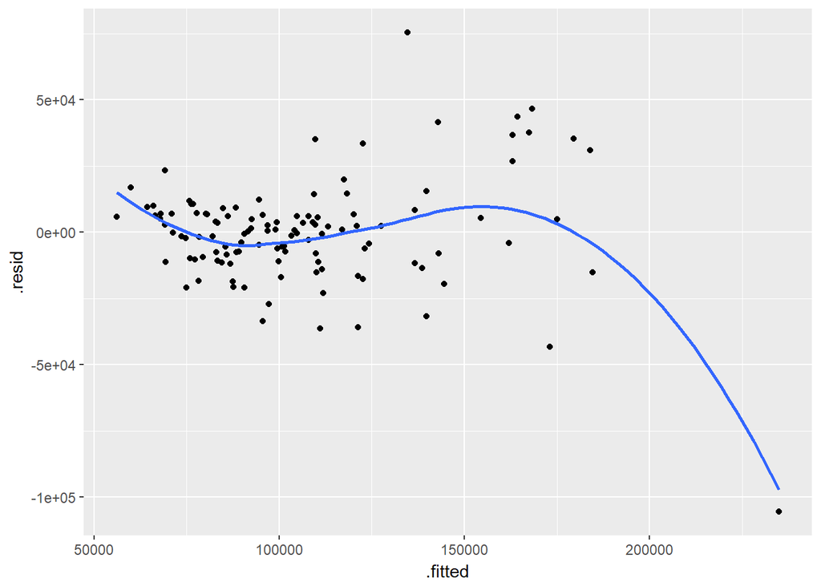

```r
ggplot(sqft_predictions, aes(x=.fitted, y=.resid)) +
  geom_point() +
  geom_smooth(method=loess, se=FALSE)
```

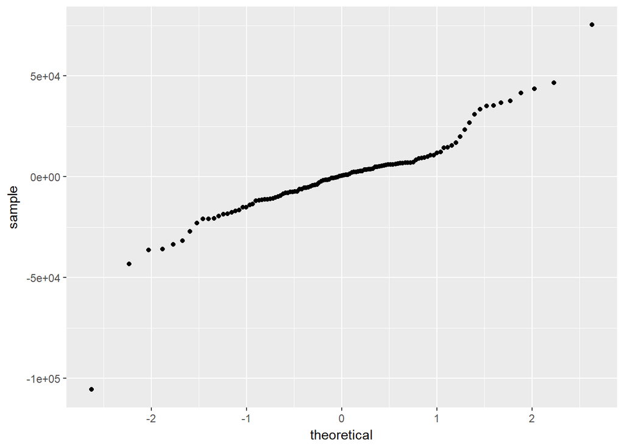

```r
ggplot(sqft_predictions) +
  stat_qq(aes(sample=.resid))
```

When you have a binary predictor, you should code the two categories as 0 and 1 (known among the statistics cognescenti as an indicator variable). This is already done for us in the Albuquerque data set.

```r
cust_model <- lm(price~cust, data=ab)
glance(cust_model)
```

```
##   r.squared adj.r.squared    sigma statistic     p.value df    logLik
## 1 0.3083492     0.3023348 31776.51  51.26887 8.15936e-11  2 -1377.886
##        AIC      BIC     deviance df.residual
## 1 2761.771 2770.058 116120891222         115
```

```r
cust_coefficients <- tidy(cust_model)
cust_coefficients
```

```
##          term estimate std.error statistic      p.value
## 1 (Intercept) 94752.22  3349.539 28.288140 1.263901e-53
## 2        cust 49925.56  6972.621  7.160228 8.159360e-11
```

```r
cust_coefficients %>%
  filter(term=="(Intercept)") %>%
  select(estimate) %>%
  as.numeric -> cust_intercept
cust_coefficients %>%
  filter(term=="cust") %>%
  select(estimate) %>%
  as.numeric -> cust_slope
cust_new_predictions <- augment(cust_model, newdata=data.frame(cust=c(0, 1)))
cust_new_predictions
```

```
##   cust   .fitted  .se.fit
## 1    0  94752.22 3349.539
## 2    1 144677.78 6115.393
```

```r
cust_new_predictions %>%
  filter(cust==0) %>%
  select(.fitted) %>%
  as.numeric -> predict_at_0
cust_new_predictions %>%
  filter(cust==1) %>%
  select(.fitted) %>%
  as.numeric -> predict_at_1
predict_difference <- predict_at_1 - predict_at_0
predict_midpoint <- (predict_at_0 + predict_at_1) / 2
ab %>%
  group_by(cust) %>%
  summarize(mean_price=mean(price)) %>%
  ungroup -> group_means
group_means
```

```
## # A tibble: 2 × 2
##    cust mean_price
##   <int>      <dbl>
## 1     0   94752.22
## 2     1  144677.78
```

Normally, you would use a boxplot to describe the relationship between a categorical variable like cust and a continuous variable like price. But I will show a scatterplot here because it better illustrates the mechanics of linear regression with an indicator variable.

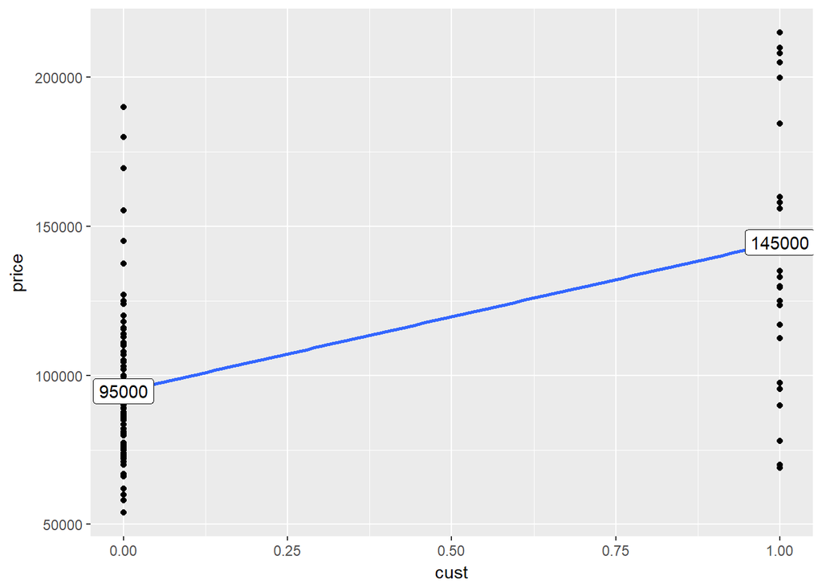

```r
ggplot(ab, aes(x=cust, y=price)) +
  geom_point() +
  geom_smooth(method="lm", se=FALSE) +
  geom_label(x=0, y=predict_at_0, label=round(predict_at_0, -3)) +
  geom_label(x=1, y=predict_at_1, label=round(predict_at_1, -3))
```

The intercept is the estimated average value of Y when X=0, so in this example, it means that the estimated average price of normal (non-custom-built) houses is 95 thousand dollars. The slope is the estimated average change in Y when X increases by one unit. In this example, it means that the estimated average price increases by 50 thousand dollars when you swtich from a normal to a custom-built home.

When you include two independent variables (call them X1 and X2) in a linear regression model, the interpretation changes slightly. The intercept is the estimated average value of Y when both X1 and X2 are equal to zero. The slope for X1 is the estimated average change in Y when X1 increases by one unit and X2 remains constant. The slope for X2 is the estimated average change in Y when X2 increases by one unit and X1 remains constant.

This concept of holding a variable constant is the foundation for risk-adjusted regression models.

In the Albuquerque housing data set, it turns out that the two independent variables sqft and cust are closely related. Custom-built houses tend to be bigger than normal houses and bigger houses are more likely to be custom-built. So is the large discrepancy in average prices between regular and custom-built homes just because custom-built houses are bigger? Put both sqft and cust in a linear regression model and see what happens.

```r
adjusted_model <- lm(price~sqft+cust, data=ab)
adjusted_coefficients <- tidy(adjusted_model)
adjusted_coefficients
```

```
##          term    estimate   std.error statistic      p.value
## 1 (Intercept) 11413.48244 6549.924264  1.742537 8.411128e-02
## 2        sqft    55.36354    4.122939 13.428172 3.146228e-25
## 3        cust 14285.99306 5103.019494  2.799518 6.012155e-03
```

```r
adjusted_coefficients %>%
  filter(term=="cust") %>%
  select(estimate) %>%
  as.numeric -> adjusted_cust_slope
adjusted_coefficients %>%
  filter(term=="sqft") %>%
  select(estimate) %>%
  as.numeric -> adjusted_sqft_slope
adjusted_coefficients %>%
  filter(term=="(Intercept)") %>%
  select(estimate) %>%
  as.numeric -> intercept_normal
intercept_custom <- intercept_normal + adjusted_cust_slope
ab %>%
  filter(cust==0) %>%
  summarize(sqft=mean(sqft), price=mean(price)) %>%
  mutate(label=paste(round(sqft, -1), round(price, -3), sep=", ")) -> normal_mean
normal_mean
```

```
##     sqft    price       label
## 1 1505.3 94752.22 1510, 95000
```

```r
ab %>%
  filter(cust==1) %>%
  summarize(sqft=mean(sqft), price=mean(price))  %>%
  mutate(label=paste(round(sqft, -1), round(price, -3), sep=", ")) -> custom_mean
ab %>%
  summarize(sqft=mean(sqft)) %>%
  mutate(normal=intercept_normal + adjusted_sqft_slope*sqft)  %>%
  mutate(nlabel=paste(round(sqft, -1), round(normal, -3), sep=", ")) %>%
  mutate(custom=intercept_custom + adjusted_sqft_slope*sqft)  %>%
  mutate(clabel=paste(round(sqft, -1), round(custom, -3), sep=", ")) -> overall_mean
```

The estimated average price of a home is 14 thousand dollars more expensive, on average, than a normal home when the size of the home is held constant.

This is still statistically significant, but substantially smaller than the unadjusted estimate (50 thousand dollars). So about 71% of the difference in the average price of custom versus normal homes can be accounted for by the difference in sizes.

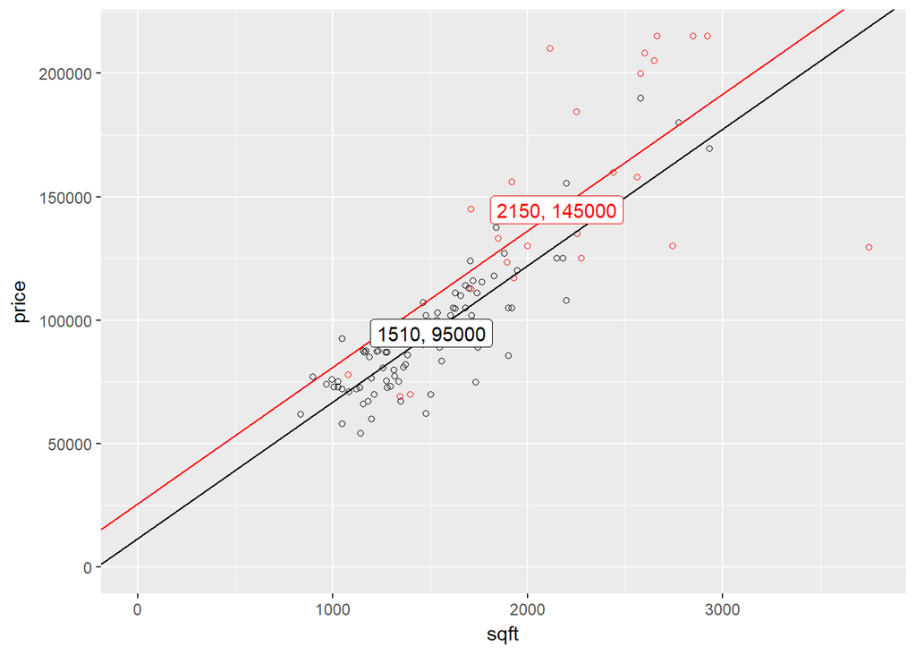

```r
ggplot(ab) +
  geom_point(aes(x=sqft, y=price, color=factor(cust)), shape=1) +
  theme(legend.position="none") +
  expand_limits(x=0, y=0) +
  scale_color_manual(values=c("0"="black", "1"="red")) +
  geom_abline(slope=adjusted_sqft_slope, intercept=intercept_normal, color="black") +
  geom_abline(slope=adjusted_sqft_slope, intercept=intercept_custom, color="red") +
  geom_label(x=normal_mean$sqft, y=normal_mean$price, label=normal_mean$label, color="black") +
  geom_label(x=custom_mean$sqft, y=custom_mean$price, label=custom_mean$label, color="red")
```

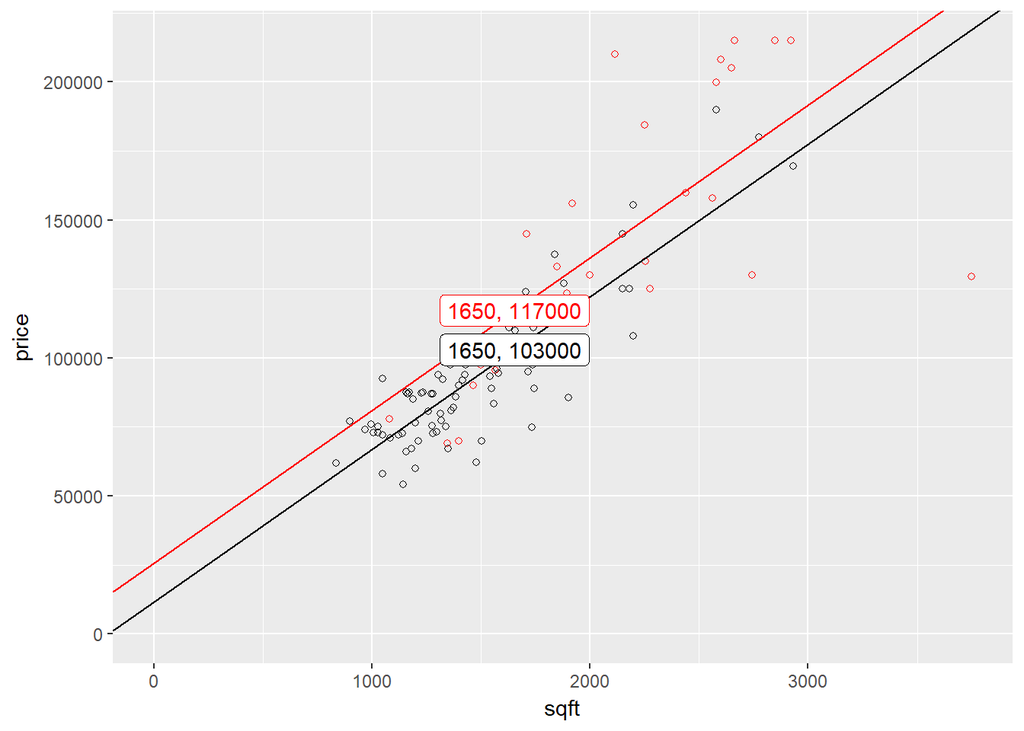

```r
ggplot(ab) +
  geom_point(aes(x=sqft, y=price, color=factor(cust)), shape=1) +
  theme(legend.position="none") +
  expand_limits(x=0, y=0) +
  scale_color_manual(values=c("0"="black", "1"="red")) +
  geom_abline(slope=adjusted_sqft_slope, intercept=intercept_normal, color="black") +
  geom_abline(slope=adjusted_sqft_slope, intercept=intercept_custom, color="red") +
  geom_label(x=overall_mean$sqft, y=overall_mean$normal, label=overall_mean$nlabel, color="black") +
  geom_label(x=overall_mean$sqft, y=overall_mean$custom, label=overall_mean$clabel, color="red")
```